# Orvac Simulation Results

Mark Jones

2019-03-12 09:38:44

# 1 Preamble

Add frequenist power/ss.

Start with frequentist properties of single analysis log rank test (one sided 0.05) at 1000 with survival times (30, 35), (30, 39) etc. Adding assumptions on accrual ltfo etc reduces power.

t0, t1, hr, , power 15, 20, 0.75, 0.998 15, 25, 0.6, 1 30, 35, 0.8571, 0.785 30, 39, 0.7692, 0.993 30, 45, 0.6667, 1.0 40, 45, 0.8889, 0.576 40, 50, 0.8, 0.963

Binomial (chisq test one sided 0.05) based on n = 250. Note - baseline rate influences power.

p0, p1, pwr 0.05, 0.15, 0.852 0.2, 0.25, 0.242 0.2, 0.30, 0.572 0.3, 0.35, 0.211 0.3, 0.40, 0.506 0.3, 0.45, 0.791 0.3, 0.50, 0.948 0.4, 0.50, 0.477 0.4, 0.55, 0.770 0.4, 0.60, 0.934

Then trial with no information delay only superiority for both endpoints.

Correct the type i error by adjusting posterior threshold

Add in futility to sero

Add in futility to tte

Add information delay (only relevant to sero)

# 2 Results from simulation scenarios

The following tables and plots summarise the scenarios that were simulated.

Analysis is all based on conjugate priors (vaguely informative for the time to event).

For the clinical endpoint we assess whether the probability of the ratio of survival times is greater than 1 (equivalent to ratio or rates). Threshold for deciding superiority was 0.96 at each interim and 0.95 at the final analysis. For the futility check, each trial simulated conditional on the current posterior was assessed against a threshold of 0.95 and if less than 5% of the trials were successful futility is declared.

For the immunological endpoint we assess whether the difference in seroconversion rates is greater than 0 (treatment versus control, i.e. one-sided). Stopping venous sampling was based on a threshold of 0.95, as was the final analysis. For the futility check, each trial simulated conditional on the current posterior was assessed against a threshold of 0.95 and if less than 5% of the trials were successful futility is declared.

## 2.1 Reading the tables

From left to right tables show:

- true median survival time (both arms)
- true seroconversion probabilities (both arms)
- accrual – number of people per 3 month period (i.e. time between interims)
- information delay (in months) to obtain seroconversion results
- probability of expected success
- probability of expected futility
- probability of stopping venous sampling
- probability of no decision
- mean (sd) of participants enrolled
- mean (sd) of participants with blood sample results
- probability that trial stops before 250, 500 and 750 enrolled participants
- number of events in each arm (ctl/trt) at time trial stopped
- proportion of trials where the final analysis indicated a treatment difference in clinical endpoint
- proportion of trials where the final analysis indicated a treatment difference in immunological endpoint
- proportion of trials where the interim decision and final analysis were consistent for clinical endpoint
- proportion of trials where the interim decision and final analysis were consistent for immunological endpoint

## 2.2 Type I Error

Baseline seroconversion rate equal to 0.3, baseline median event time equal to 30 months.

Table 1. Simulation Null Scenarios

| Clinical ctl | Clinical trt | Seroconversion ctl | Seroconversion trt | Info rate accrual | Info rate delay | Interim e.s. | Interim e.f | Interim s.v. | Interim n.d | SS enrolled | SS blood res | SS P(<250) | SS P(<500) | SS P(<750) | SS evnts | Wins @ final clin | Wins @ final immu | !Flip-flop clin | !Flip-flop immu | fname |
| --- | --- | --- | --- | --- | --- | --- | --- | --- | --- | --- | --- | --- | --- | --- | --- | --- | --- | --- | --- | --- |
| 30 | 30 | 0.3 | 0.3 | 60 | 1 | 0.020 | 0.978 | 0.036 | 0.002 | 192 (144.4) | 139 (67.2) | 0.72 | 0.96 | 0.98 | 10/10 | 0.056 | 0.047 | 0.93 | 0.91 | 2019-03-05-14-07-20 |
| 30 | 30 | 0.3 | 0.3 | 40 | 1 | 0.028 | 0.970 | 0.051 | 0.002 | 179 (142.2) | 130 (60.0) | 0.89 | 0.96 | 0.98 | 13/13 | 0.053 | 0.049 | 0.93 | 0.90 | 2019-03-05-13-48-22 |
| 30 | 30 | 0.3 | 0.3 | 20 | 1 | 0.042 | 0.956 | 0.221 | 0.002 | 177 (166.4) | 119 (52.3) | 0.85 | 0.94 | 0.97 | 22/22 | 0.055 | 0.047 | 0.93 | 0.82 | 2019-03-05-13-19-36 |
| 30 | 30 | 0.3 | 0.3 | 60 | 0 | 0.039 | 0.956 | 0.110 | 0.005 | 208 (194.1) | 137 (62.3) | 0.77 | 0.91 | 0.96 | 15/15 | 0.055 | 0.048 | 0.93 | 0.81 | 2019-03-05-12-03-55 |
| 30 | 30 | 0.3 | 0.3 | 40 | 0 | 0.033 | 0.964 | 0.117 | 0.003 | 172 (145.4) | 128 (56.1) | 0.89 | 0.96 | 0.98 | 13/13 | 0.056 | 0.049 | 0.93 | 0.89 | 2019-03-05-11-32-21 |
| 30 | 30 | 0.3 | 0.3 | 20 | 0 | 0.037 | 0.962 | 0.135 | 0.001 | 171 (161.2) | 119 (53.5) | 0.86 | 0.95 | 0.98 | 21/21 | 0.057 | 0.050 | 0.93 | 0.83 | 2019-03-05-11-03-50 |

## 2.3 Expected Success

Baseline seroconversion rate equal to 0.3, baseline median event time equal to 30 months.

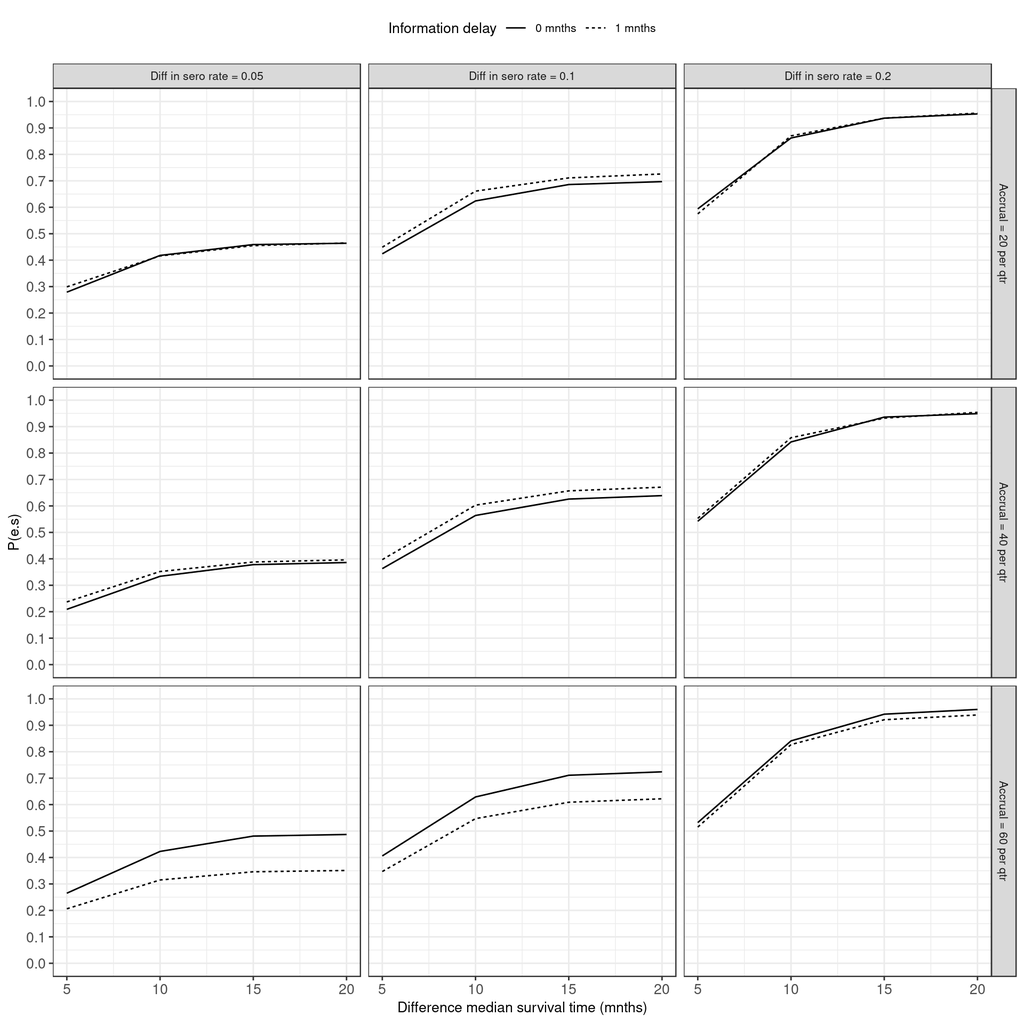

## 2.4 (Expected) Futility

Baseline seroconversion rate equal to 0.3, baseline median event time equal to 30 months.

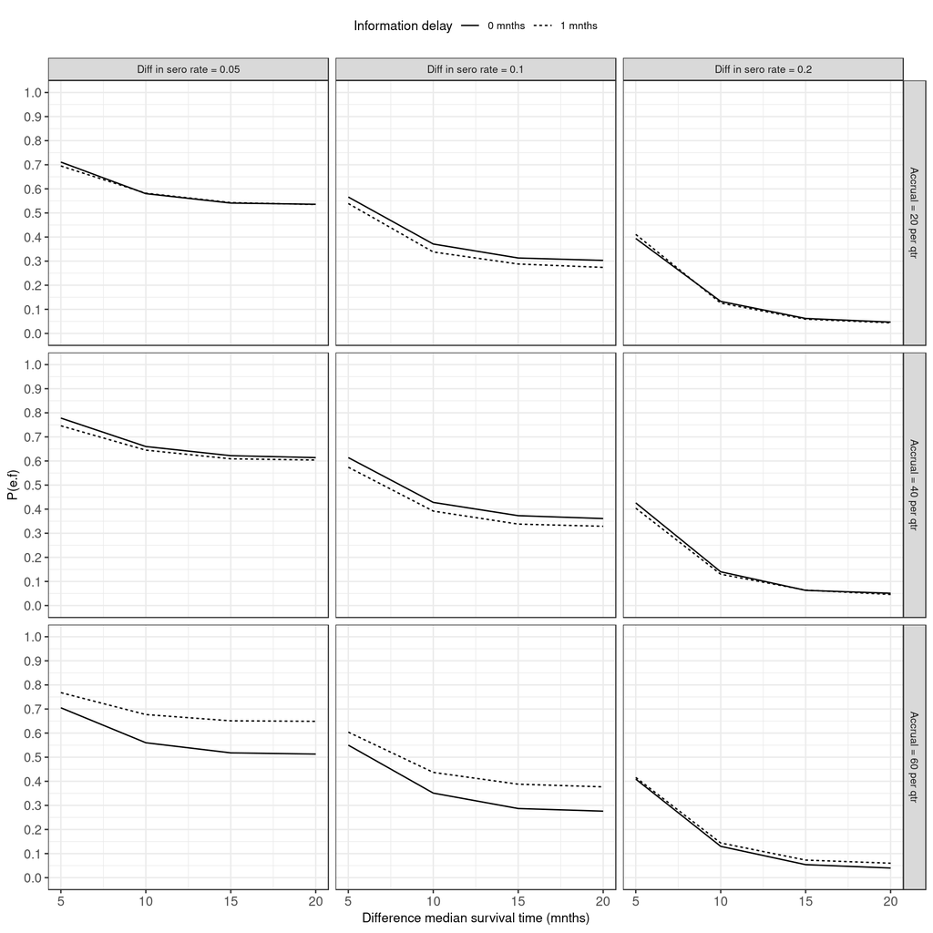

## 2.5 Stop Venous Sampling

Baseline seroconversion rate equal to 0.3, baseline median event time equal to 30 months.

Will check the switch for the lowest accrual rate result.

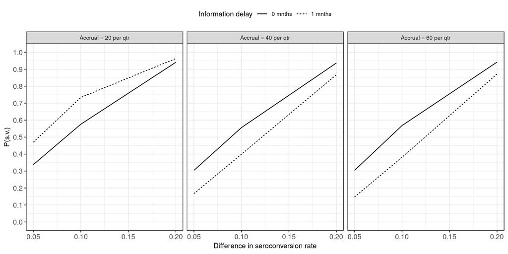

## 2.6 No Decision (Inconclusive)

Baseline seroconversion rate equal to 0.3, baseline median event time equal to 30 months.

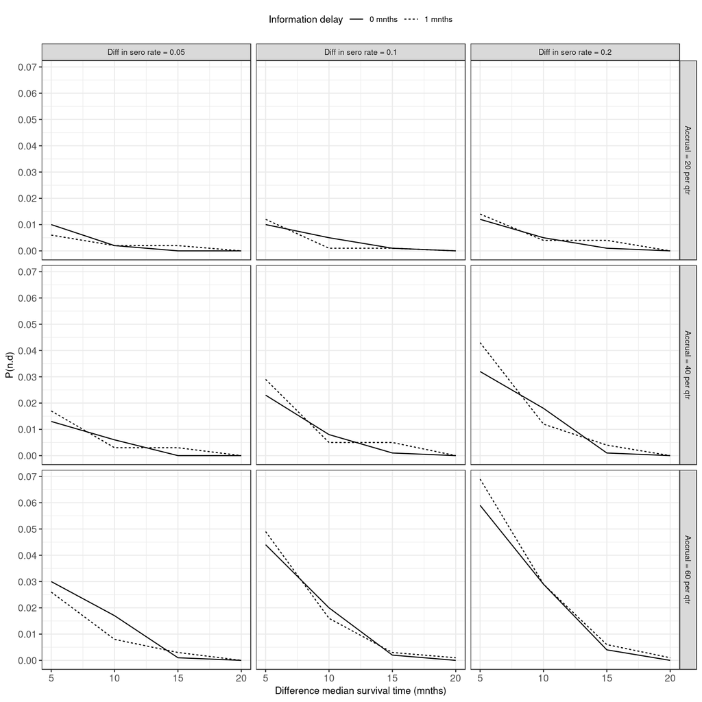

## 2.7 Sample Size

Baseline seroconversion rate equal to 0.3, baseline median event time equal to 30 months.

### 2.7.1 Total Enrolled

Note - information delay is 1 months (zero information delay showed as fainter line).

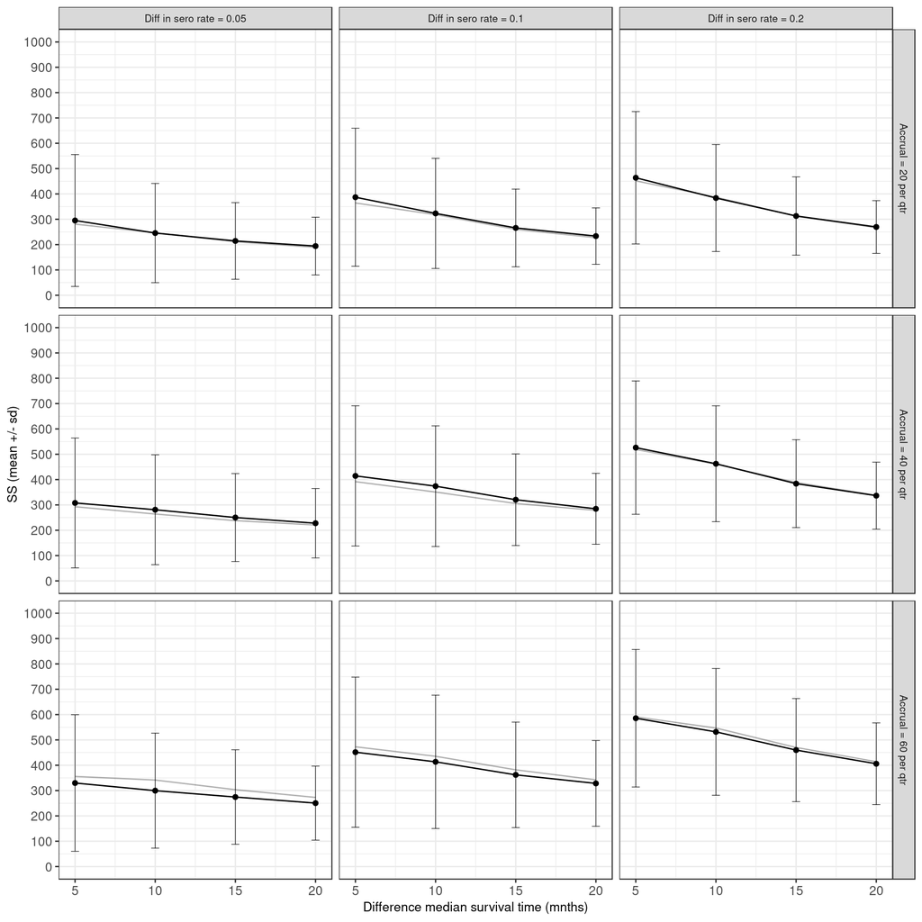

### 2.7.2 Cohort with Bloods Taken

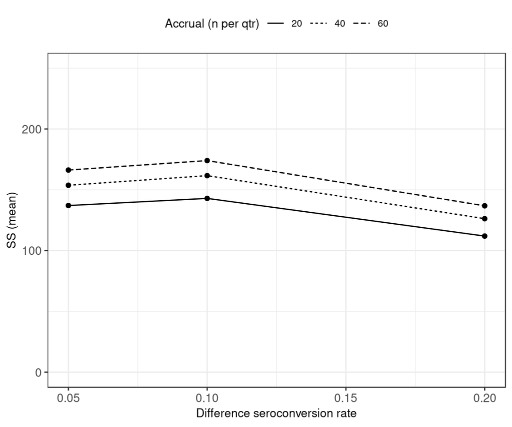

## 2.8 Consistency of Interim Decision with Final Analysis (flip-flop)

Shows the proportion of times that the final analysis is consistent with the interim decision that was made.

Baseline seroconversion rate equal to 0.3, baseline median event time equal to 30 months.

### 2.8.1 Clinical

Difference in sero of 0.05 still has quite high chance of futility.

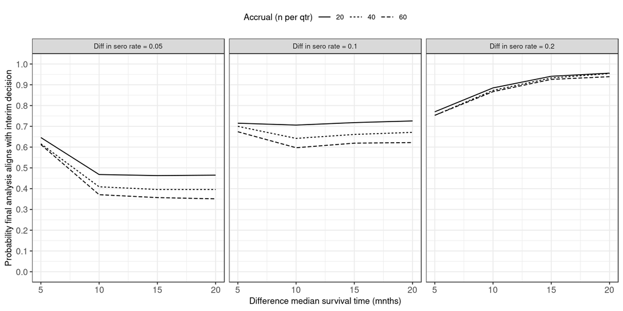

### 2.8.2 Immunological

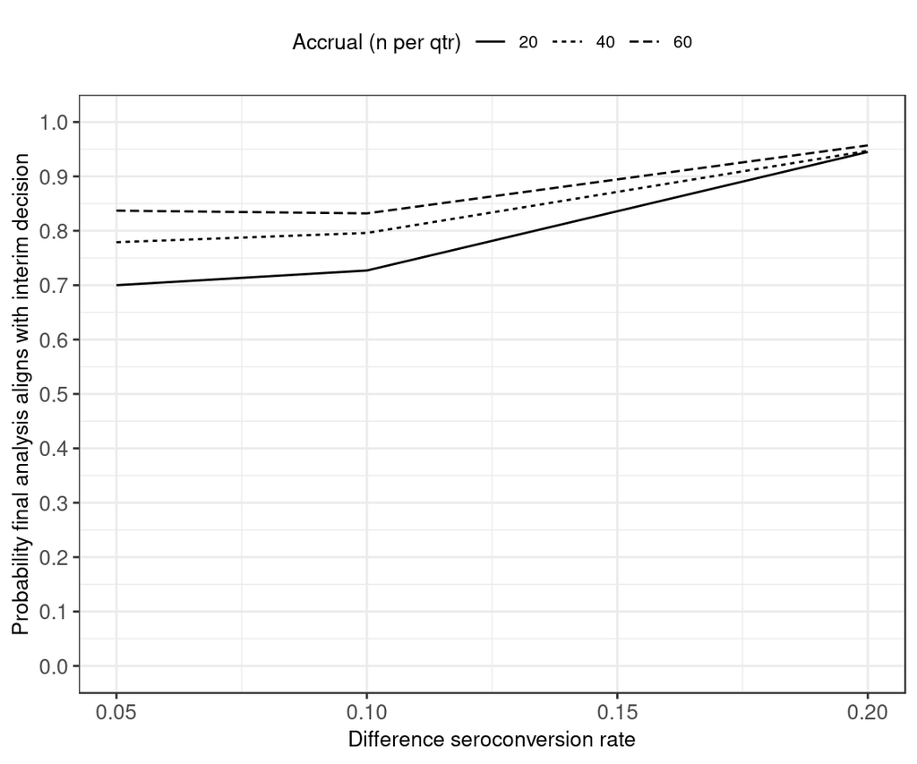

## 2.9 Combined Results

Table 2. Combined Simulation Results

| Clinical ctl | Clinical trt | Seroconversion ctl | Seroconversion trt | Info rate accrual | Info rate delay | Interim e.s. | Interim e.f | Interim s.v. | Interim n.d | SS enrolled | SS blood res | SS P(<250) | SS P(<500) | SS P(<750) | SS evnts | Wins @ final clin | Wins @ final immu | !Flip-flop clin | !Flip-flop immu | fname |
| --- | --- | --- | --- | --- | --- | --- | --- | --- | --- | --- | --- | --- | --- | --- | --- | --- | --- | --- | --- | --- |
| 30 | 50 | 0.3 | 0.50 | 60 | 1 | 0.939 | 0.060 | 0.872 | 0.001 | 406 (161.2) | 137 (63.9) | 0.03 | 0.77 | 0.97 | 36/23 | 1.000 | 0.950 | 0.94 | 0.96 | 2019-03-12-03-33-02 |
| 30 | 45 | 0.3 | 0.50 | 60 | 1 | 0.921 | 0.073 | 0.872 | 0.006 | 460 (203.5) | 137 (63.9) | 0.03 | 0.66 | 0.91 | 49/34 | 0.991 | 0.949 | 0.93 | 0.96 | 2019-03-12-01-57-44 |
| 30 | 40 | 0.3 | 0.50 | 60 | 1 | 0.827 | 0.144 | 0.872 | 0.029 | 532 (250.3) | 137 (63.9) | 0.03 | 0.54 | 0.79 | 69/53 | 0.920 | 0.950 | 0.87 | 0.96 | 2019-03-12-00-00-31 |
| 30 | 35 | 0.3 | 0.50 | 60 | 1 | 0.515 | 0.416 | 0.872 | 0.069 | 586 (271.5) | 137 (64.0) | 0.03 | 0.48 | 0.69 | 84/72 | 0.502 | 0.947 | 0.75 | 0.96 | 2019-03-11-21-35-29 |
| 30 | 50 | 0.3 | 0.40 | 60 | 1 | 0.622 | 0.377 | 0.379 | 0.001 | 328 (169.3) | 174 (65.6) | 0.22 | 0.86 | 0.98 | 26/16 | 1.000 | 0.503 | 0.62 | 0.83 | 2019-03-11-18-48-51 |
| 30 | 45 | 0.3 | 0.40 | 60 | 1 | 0.609 | 0.388 | 0.380 | 0.003 | 362 (208.2) | 174 (65.7) | 0.22 | 0.79 | 0.94 | 33/23 | 0.990 | 0.507 | 0.62 | 0.83 | 2019-03-11-17-44-35 |
| 30 | 40 | 0.3 | 0.40 | 60 | 1 | 0.547 | 0.437 | 0.380 | 0.016 | 413 (263.2) | 174 (65.9) | 0.22 | 0.70 | 0.86 | 47/36 | 0.926 | 0.502 | 0.60 | 0.83 | 2019-03-11-16-26-48 |
| 30 | 35 | 0.3 | 0.40 | 60 | 1 | 0.347 | 0.604 | 0.381 | 0.049 | 451 (296.4) | 174 (65.8) | 0.22 | 0.65 | 0.79 | 59/50 | 0.515 | 0.508 | 0.67 | 0.83 | 2019-03-11-14-48-39 |
| 30 | 50 | 0.3 | 0.35 | 60 | 1 | 0.351 | 0.649 | 0.147 | 0.000 | 250 (146.1) | 166 (66.4) | 0.46 | 0.94 | 0.99 | 15/10 | 1.000 | 0.214 | 0.35 | 0.83 | 2019-03-11-12-55-47 |
| 30 | 45 | 0.3 | 0.35 | 60 | 1 | 0.346 | 0.651 | 0.147 | 0.003 | 274 (186.4) | 166 (66.4) | 0.46 | 0.90 | 0.97 | 21/14 | 0.989 | 0.214 | 0.36 | 0.83 | 2019-03-11-12-20-27 |
| 30 | 40 | 0.3 | 0.35 | 60 | 1 | 0.315 | 0.677 | 0.146 | 0.008 | 300 (226.9) | 166 (66.4) | 0.46 | 0.84 | 0.94 | 27/21 | 0.922 | 0.208 | 0.37 | 0.82 | 2019-03-11-11-35-24 |
| 30 | 35 | 0.3 | 0.35 | 60 | 1 | 0.206 | 0.768 | 0.147 | 0.026 | 330 (269.7) | 166 (66.4) | 0.46 | 0.80 | 0.88 | 36/30 | 0.512 | 0.222 | 0.61 | 0.84 | 2019-03-11-10-39-56 |
| 30 | 50 | 0.3 | 0.50 | 40 | 1 | 0.954 | 0.046 | 0.867 | 0.000 | 337 (132.3) | 126 (57.6) | 0.30 | 0.88 | 0.99 | 36/23 | 1.000 | 0.949 | 0.95 | 0.95 | 2019-03-11-09-32-56 |
| 30 | 45 | 0.3 | 0.50 | 40 | 1 | 0.932 | 0.064 | 0.867 | 0.004 | 384 (173.4) | 126 (57.6) | 0.24 | 0.77 | 0.95 | 47/33 | 0.993 | 0.951 | 0.93 | 0.95 | 2019-03-11-07-48-51 |
| 30 | 40 | 0.3 | 0.50 | 40 | 1 | 0.858 | 0.130 | 0.868 | 0.012 | 462 (228.7) | 126 (57.6) | 0.18 | 0.63 | 0.85 | 67/52 | 0.917 | 0.951 | 0.87 | 0.95 | 2019-03-11-05-33-25 |
| 30 | 35 | 0.3 | 0.50 | 40 | 1 | 0.553 | 0.404 | 0.868 | 0.043 | 526 (263.1) | 126 (57.7) | 0.15 | 0.53 | 0.75 | 83/72 | 0.510 | 0.949 | 0.75 | 0.95 | 2019-03-11-02-28-14 |
| 30 | 50 | 0.3 | 0.40 | 40 | 1 | 0.671 | 0.329 | 0.397 | 0.000 | 285 (140.1) | 162 (59.2) | 0.51 | 0.92 | 0.99 | 28/18 | 1.000 | 0.503 | 0.67 | 0.79 | 2019-03-10-22-41-47 |
| 30 | 45 | 0.3 | 0.40 | 40 | 1 | 0.657 | 0.338 | 0.400 | 0.005 | 320 (180.9) | 162 (59.3) | 0.46 | 0.84 | 0.97 | 36/26 | 0.992 | 0.503 | 0.66 | 0.79 | 2019-03-10-21-24-51 |
| 30 | 40 | 0.3 | 0.40 | 40 | 1 | 0.603 | 0.392 | 0.399 | 0.005 | 374 (238.1) | 162 (59.3) | 0.42 | 0.74 | 0.89 | 49/38 | 0.921 | 0.505 | 0.64 | 0.79 | 2019-03-10-19-44-44 |
| 30 | 35 | 0.3 | 0.40 | 40 | 1 | 0.397 | 0.574 | 0.399 | 0.029 | 415 (276.8) | 162 (59.3) | 0.41 | 0.68 | 0.82 | 60/52 | 0.511 | 0.509 | 0.70 | 0.80 | 2019-03-10-17-31-36 |
| 30 | 50 | 0.3 | 0.35 | 40 | 1 | 0.396 | 0.604 | 0.168 | 0.000 | 228 (136.9) | 154 (60.6) | 0.72 | 0.95 | 0.99 | 19/12 | 1.000 | 0.210 | 0.40 | 0.78 | 2019-03-10-14-51-37 |
| 30 | 45 | 0.3 | 0.35 | 40 | 1 | 0.388 | 0.609 | 0.168 | 0.003 | 250 (173.6) | 154 (60.6) | 0.68 | 0.90 | 0.98 | 24/17 | 0.992 | 0.217 | 0.40 | 0.79 | 2019-03-10-14-02-47 |
| 30 | 40 | 0.3 | 0.35 | 40 | 1 | 0.352 | 0.645 | 0.167 | 0.003 | 281 (217.0) | 154 (60.6) | 0.65 | 0.84 | 0.94 | 32/25 | 0.919 | 0.207 | 0.41 | 0.78 | 2019-03-10-13-01-33 |
| 30 | 35 | 0.3 | 0.35 | 40 | 1 | 0.237 | 0.746 | 0.167 | 0.017 | 308 (256.3) | 154 (60.6) | 0.64 | 0.80 | 0.89 | 39/34 | 0.511 | 0.209 | 0.62 | 0.78 | 2019-03-10-11-39-17 |
| 30 | 50 | 0.3 | 0.50 | 20 | 1 | 0.956 | 0.044 | 0.963 | 0.000 | 270 (104.0) | 112 (48.9) | 0.57 | 0.96 | 0.99 | 40/26 | 1.000 | 0.949 | 0.96 | 0.95 | 2019-03-10-10-01-04 |
| 30 | 45 | 0.3 | 0.50 | 20 | 1 | 0.937 | 0.059 | 0.963 | 0.004 | 313 (154.5) | 112 (48.9) | 0.47 | 0.88 | 0.97 | 51/36 | 0.992 | 0.948 | 0.94 | 0.94 | 2019-03-10-07-54-08 |
| 30 | 40 | 0.3 | 0.50 | 20 | 1 | 0.870 | 0.126 | 0.963 | 0.004 | 384 (211.2) | 112 (49.0) | 0.34 | 0.76 | 0.92 | 68/53 | 0.919 | 0.946 | 0.89 | 0.94 | 2019-03-10-04-48-02 |
| 30 | 35 | 0.3 | 0.50 | 20 | 1 | 0.575 | 0.411 | 0.963 | 0.014 | 464 (261.2) | 112 (48.9) | 0.28 | 0.61 | 0.80 | 87/77 | 0.505 | 0.948 | 0.77 | 0.94 | 2019-03-10-00-08-41 |
| 30 | 50 | 0.3 | 0.40 | 20 | 1 | 0.726 | 0.274 | 0.732 | 0.000 | 234 (111.4) | 143 (54.2) | 0.68 | 0.97 | 1.00 | 32/21 | 1.000 | 0.508 | 0.73 | 0.72 | 2019-03-09-17-43-41 |
| 30 | 45 | 0.3 | 0.40 | 20 | 1 | 0.711 | 0.288 | 0.733 | 0.001 | 266 (153.2) | 143 (54.2) | 0.59 | 0.91 | 0.98 | 40/29 | 0.991 | 0.509 | 0.72 | 0.72 | 2019-03-09-16-03-49 |
| 30 | 40 | 0.3 | 0.40 | 20 | 1 | 0.661 | 0.338 | 0.734 | 0.001 | 323 (217.4) | 143 (54.2) | 0.50 | 0.81 | 0.93 | 54/43 | 0.915 | 0.515 | 0.71 | 0.72 | 2019-03-09-13-43-25 |
| 30 | 35 | 0.3 | 0.40 | 20 | 1 | 0.449 | 0.539 | 0.734 | 0.012 | 387 (272.4) | 143 (54.2) | 0.45 | 0.70 | 0.85 | 70/61 | 0.510 | 0.519 | 0.71 | 0.73 | 2019-03-09-10-03-54 |
| 30 | 50 | 0.3 | 0.35 | 20 | 1 | 0.465 | 0.535 | 0.470 | 0.000 | 194 (113.9) | 137 (54.0) | 0.79 | 0.98 | 0.99 | 24/16 | 1.000 | 0.217 | 0.47 | 0.71 | 2019-03-09-05-01-10 |
| 30 | 45 | 0.3 | 0.35 | 20 | 1 | 0.455 | 0.543 | 0.470 | 0.002 | 214 (151.2) | 137 (54.0) | 0.74 | 0.94 | 0.98 | 29/21 | 0.992 | 0.212 | 0.46 | 0.70 | 2019-03-09-03-49-35 |
| 30 | 40 | 0.3 | 0.35 | 20 | 1 | 0.416 | 0.582 | 0.470 | 0.002 | 246 (195.9) | 137 (53.9) | 0.68 | 0.88 | 0.96 | 37/29 | 0.914 | 0.209 | 0.47 | 0.70 | 2019-03-09-02-13-04 |
| 30 | 35 | 0.3 | 0.35 | 20 | 1 | 0.299 | 0.695 | 0.470 | 0.006 | 295 (260.3) | 137 (53.9) | 0.64 | 0.80 | 0.89 | 49/43 | 0.513 | 0.208 | 0.65 | 0.70 | 2019-03-08-23-54-12 |
| 30 | 50 | 0.3 | 0.50 | 60 | 0 | 0.960 | 0.040 | 0.943 | 0.000 | 414 (163.4) | 115 (56.8) | 0.03 | 0.76 | 0.96 | 38/24 | 1.000 | 0.944 | 0.96 | 0.95 | 2019-03-08-20-30-43 |
| 30 | 45 | 0.3 | 0.50 | 60 | 0 | 0.942 | 0.054 | 0.943 | 0.004 | 470 (203.3) | 115 (56.8) | 0.03 | 0.65 | 0.90 | 51/36 | 0.991 | 0.943 | 0.94 | 0.95 | 2019-03-08-18-54-11 |
| 30 | 40 | 0.3 | 0.50 | 60 | 0 | 0.841 | 0.130 | 0.942 | 0.029 | 547 (247.2) | 116 (56.9) | 0.03 | 0.51 | 0.78 | 72/56 | 0.913 | 0.943 | 0.87 | 0.95 | 2019-03-08-16-54-41 |
| 30 | 35 | 0.3 | 0.50 | 60 | 0 | 0.532 | 0.409 | 0.942 | 0.059 | 591 (270.9) | 116 (56.9) | 0.03 | 0.46 | 0.68 | 85/73 | 0.515 | 0.941 | 0.78 | 0.94 | 2019-03-08-14-25-04 |
| 30 | 50 | 0.3 | 0.40 | 60 | 0 | 0.724 | 0.276 | 0.569 | 0.000 | 342 (189.0) | 153 (69.9) | 0.27 | 0.83 | 0.97 | 29/18 | 1.000 | 0.488 | 0.72 | 0.72 | 2019-03-08-11-37-58 |
| 30 | 45 | 0.3 | 0.40 | 60 | 0 | 0.711 | 0.287 | 0.569 | 0.002 | 382 (228.5) | 153 (69.9) | 0.27 | 0.74 | 0.93 | 38/27 | 0.994 | 0.486 | 0.71 | 0.71 | 2019-03-08-10-24-48 |
| 30 | 40 | 0.3 | 0.40 | 60 | 0 | 0.629 | 0.351 | 0.569 | 0.020 | 435 (278.4) | 153 (69.9) | 0.27 | 0.65 | 0.84 | 53/41 | 0.910 | 0.492 | 0.68 | 0.72 | 2019-03-08-08-55-32 |
| 30 | 35 | 0.3 | 0.40 | 60 | 0 | 0.406 | 0.550 | 0.568 | 0.044 | 473 (304.7) | 153 (69.9) | 0.27 | 0.59 | 0.77 | 64/55 | 0.521 | 0.485 | 0.70 | 0.71 | 2019-03-08-07-04-40 |
| 30 | 50 | 0.3 | 0.35 | 60 | 0 | 0.487 | 0.513 | 0.303 | 0.000 | 273 (185.0) | 155 (67.9) | 0.51 | 0.88 | 0.98 | 20/13 | 1.000 | 0.200 | 0.49 | 0.69 | 2019-03-08-05-00-11 |
| 30 | 45 | 0.3 | 0.35 | 60 | 0 | 0.481 | 0.518 | 0.303 | 0.001 | 303 (226.9) | 155 (67.9) | 0.51 | 0.81 | 0.95 | 27/19 | 0.993 | 0.202 | 0.48 | 0.69 | 2019-03-08-04-09-28 |
| 30 | 40 | 0.3 | 0.35 | 60 | 0 | 0.423 | 0.560 | 0.304 | 0.017 | 342 (276.3) | 155 (67.9) | 0.51 | 0.75 | 0.89 | 38/30 | 0.912 | 0.206 | 0.48 | 0.70 | 2019-03-08-03-06-38 |
| 30 | 35 | 0.3 | 0.35 | 60 | 0 | 0.265 | 0.705 | 0.304 | 0.030 | 356 (293.6) | 155 (67.9) | 0.51 | 0.74 | 0.86 | 42/36 | 0.520 | 0.208 | 0.62 | 0.70 | 2019-03-08-01-49-03 |
| 30 | 50 | 0.3 | 0.50 | 40 | 0 | 0.949 | 0.051 | 0.937 | 0.000 | 338 (132.3) | 106 (47.4) | 0.31 | 0.88 | 0.98 | 36/23 | 1.000 | 0.939 | 0.95 | 0.95 | 2019-03-08-00-26-02 |
| 30 | 45 | 0.3 | 0.50 | 40 | 0 | 0.936 | 0.063 | 0.937 | 0.001 | 389 (179.4) | 106 (47.4) | 0.26 | 0.77 | 0.95 | 49/34 | 0.990 | 0.943 | 0.93 | 0.95 | 2019-03-07-22-41-54 |
| 30 | 40 | 0.3 | 0.50 | 40 | 0 | 0.842 | 0.140 | 0.937 | 0.018 | 461 (232.6) | 106 (47.4) | 0.20 | 0.62 | 0.85 | 67/52 | 0.906 | 0.941 | 0.87 | 0.95 | 2019-03-07-20-24-11 |
| 30 | 35 | 0.3 | 0.50 | 40 | 0 | 0.542 | 0.426 | 0.937 | 0.032 | 519 (263.7) | 106 (47.4) | 0.19 | 0.54 | 0.76 | 82/71 | 0.512 | 0.942 | 0.78 | 0.95 | 2019-03-07-17-21-22 |
| 30 | 50 | 0.3 | 0.40 | 40 | 0 | 0.639 | 0.361 | 0.557 | 0.000 | 279 (153.3) | 141 (61.6) | 0.55 | 0.91 | 0.98 | 27/18 | 1.000 | 0.495 | 0.64 | 0.80 | 2019-03-07-13-42-59 |
| 30 | 45 | 0.3 | 0.40 | 40 | 0 | 0.626 | 0.373 | 0.556 | 0.001 | 306 (184.1) | 141 (61.7) | 0.50 | 0.84 | 0.97 | 34/24 | 0.992 | 0.491 | 0.63 | 0.80 | 2019-03-07-12-28-24 |
| 30 | 40 | 0.3 | 0.40 | 40 | 0 | 0.564 | 0.428 | 0.555 | 0.008 | 351 (237.3) | 141 (61.7) | 0.47 | 0.76 | 0.91 | 45/35 | 0.912 | 0.487 | 0.61 | 0.79 | 2019-03-07-10-57-14 |
| 30 | 35 | 0.3 | 0.40 | 40 | 0 | 0.363 | 0.614 | 0.556 | 0.023 | 392 (276.7) | 141 (61.7) | 0.46 | 0.69 | 0.84 | 56/49 | 0.510 | 0.497 | 0.67 | 0.80 | 2019-03-07-08-57-25 |
| 30 | 50 | 0.3 | 0.35 | 40 | 0 | 0.386 | 0.614 | 0.304 | 0.000 | 221 (139.5) | 142 (60.2) | 0.73 | 0.94 | 1.00 | 19/12 | 1.000 | 0.200 | 0.39 | 0.79 | 2019-03-07-06-31-53 |
| 30 | 45 | 0.3 | 0.35 | 40 | 0 | 0.378 | 0.622 | 0.304 | 0.000 | 238 (168.9) | 143 (60.2) | 0.70 | 0.90 | 0.98 | 23/16 | 0.992 | 0.200 | 0.38 | 0.79 | 2019-03-07-05-46-26 |
| 30 | 40 | 0.3 | 0.35 | 40 | 0 | 0.334 | 0.660 | 0.304 | 0.006 | 264 (215.1) | 143 (60.2) | 0.69 | 0.85 | 0.95 | 29/23 | 0.912 | 0.197 | 0.40 | 0.79 | 2019-03-07-04-49-05 |
| 30 | 35 | 0.3 | 0.35 | 40 | 0 | 0.209 | 0.778 | 0.304 | 0.013 | 293 (257.5) | 143 (60.2) | 0.68 | 0.81 | 0.90 | 36/32 | 0.523 | 0.202 | 0.59 | 0.80 | 2019-03-07-03-34-29 |
| 30 | 50 | 0.3 | 0.50 | 20 | 0 | 0.953 | 0.047 | 0.937 | 0.000 | 267 (102.4) | 100 (41.9) | 0.59 | 0.96 | 1.00 | 40/26 | 1.000 | 0.943 | 0.95 | 0.95 | 2019-03-07-02-02-07 |
| 30 | 45 | 0.3 | 0.50 | 20 | 0 | 0.937 | 0.062 | 0.941 | 0.001 | 312 (153.2) | 100 (42.4) | 0.46 | 0.89 | 0.98 | 50/36 | 0.992 | 0.940 | 0.94 | 0.94 | 2019-03-07-00-02-35 |
| 30 | 40 | 0.3 | 0.50 | 20 | 0 | 0.862 | 0.133 | 0.940 | 0.005 | 387 (219.0) | 100 (42.6) | 0.35 | 0.76 | 0.90 | 69/55 | 0.905 | 0.939 | 0.90 | 0.94 | 2019-03-06-21-00-02 |
| 30 | 35 | 0.3 | 0.50 | 20 | 0 | 0.594 | 0.394 | 0.941 | 0.012 | 452 (255.4) | 100 (42.8) | 0.28 | 0.65 | 0.82 | 85/74 | 0.522 | 0.942 | 0.77 | 0.95 | 2019-03-06-16-17-44 |
| 30 | 50 | 0.3 | 0.40 | 20 | 0 | 0.697 | 0.303 | 0.575 | 0.000 | 227 (113.3) | 130 (58.4) | 0.70 | 0.97 | 1.00 | 31/20 | 1.000 | 0.497 | 0.70 | 0.73 | 2019-03-06-10-10-46 |
| 30 | 45 | 0.3 | 0.40 | 20 | 0 | 0.686 | 0.313 | 0.583 | 0.001 | 260 (155.7) | 130 (58.9) | 0.60 | 0.92 | 0.98 | 39/28 | 0.993 | 0.490 | 0.69 | 0.72 | 2019-03-06-08-39-11 |
| 30 | 40 | 0.3 | 0.40 | 20 | 0 | 0.624 | 0.371 | 0.581 | 0.005 | 318 (227.8) | 131 (59.8) | 0.52 | 0.82 | 0.93 | 54/43 | 0.915 | 0.491 | 0.68 | 0.73 | 2019-03-06-06-22-26 |
| 30 | 35 | 0.3 | 0.40 | 20 | 0 | 0.424 | 0.566 | 0.576 | 0.010 | 364 (263.5) | 131 (60.3) | 0.47 | 0.74 | 0.86 | 65/57 | 0.521 | 0.489 | 0.71 | 0.72 | 2019-03-06-02-50-08 |
| 30 | 50 | 0.3 | 0.35 | 20 | 0 | 0.464 | 0.536 | 0.335 | 0.000 | 189 (108.2) | 132 (57.1) | 0.79 | 0.98 | 1.00 | 24/15 | 1.000 | 0.199 | 0.46 | 0.71 | 2019-03-05-22-15-11 |
| 30 | 45 | 0.3 | 0.35 | 20 | 0 | 0.459 | 0.541 | 0.339 | 0.000 | 211 (146.7) | 132 (57.7) | 0.73 | 0.95 | 0.99 | 29/21 | 0.993 | 0.200 | 0.46 | 0.71 | 2019-03-05-21-13-30 |
| 30 | 40 | 0.3 | 0.35 | 20 | 0 | 0.418 | 0.580 | 0.341 | 0.002 | 247 (203.1) | 133 (59.1) | 0.67 | 0.88 | 0.96 | 38/30 | 0.916 | 0.198 | 0.48 | 0.71 | 2019-03-05-19-38-21 |
| 30 | 35 | 0.3 | 0.35 | 20 | 0 | 0.279 | 0.711 | 0.338 | 0.010 | 281 (250.0) | 133 (59.7) | 0.65 | 0.82 | 0.91 | 46/40 | 0.521 | 0.203 | 0.60 | 0.71 | 2019-03-05-17-14-48 |
| 30 | 30 | 0.3 | 0.30 | 60 | 1 | 0.020 | 0.978 | 0.036 | 0.002 | 192 (144.4) | 139 (67.2) | 0.72 | 0.96 | 0.98 | 10/10 | 0.056 | 0.047 | 0.93 | 0.91 | 2019-03-05-14-07-20 |
| 30 | 30 | 0.3 | 0.30 | 40 | 1 | 0.028 | 0.970 | 0.051 | 0.002 | 179 (142.2) | 130 (60.0) | 0.89 | 0.96 | 0.98 | 13/13 | 0.053 | 0.049 | 0.93 | 0.90 | 2019-03-05-13-48-22 |
| 30 | 30 | 0.3 | 0.30 | 20 | 1 | 0.042 | 0.956 | 0.221 | 0.002 | 177 (166.4) | 119 (52.3) | 0.85 | 0.94 | 0.97 | 22/22 | 0.055 | 0.047 | 0.93 | 0.82 | 2019-03-05-13-19-36 |
| 30 | 30 | 0.3 | 0.30 | 60 | 0 | 0.039 | 0.956 | 0.110 | 0.005 | 208 (194.1) | 137 (62.3) | 0.77 | 0.91 | 0.96 | 15/15 | 0.055 | 0.048 | 0.93 | 0.81 | 2019-03-05-12-03-55 |
| 30 | 30 | 0.3 | 0.30 | 40 | 0 | 0.033 | 0.964 | 0.117 | 0.003 | 172 (145.4) | 128 (56.1) | 0.89 | 0.96 | 0.98 | 13/13 | 0.056 | 0.049 | 0.93 | 0.89 | 2019-03-05-11-32-21 |
| 30 | 30 | 0.3 | 0.30 | 20 | 0 | 0.037 | 0.962 | 0.135 | 0.001 | 171 (161.2) | 119 (53.5) | 0.86 | 0.95 | 0.98 | 21/21 | 0.057 | 0.050 | 0.93 | 0.83 | 2019-03-05-11-03-50 |